# Python数据分析工具包

## 1 NumPy工具包：数值计算

NumPy（Numerical Python）是基于python语言的开源数值计算拓展工具包，它提供了高效的多维数组对象（ndarray）以及对这些数组进行操作的函数和工具，可以用来存储和处理大型矩阵（Matrix）。

### 1.1 多维数组：ndarray

Python语言本身包含了类似于C语言一维数组的array模块，但其不支持多维且不提供运算函数，因此并不适合进行复杂的数值运算。

NumPy的诞生弥补了这些不足，它提供了一种存储**单一数据类型**的**多维数组对象（ndarray）**。

ndarray是一个固定大小的多维数组，可以存储同类型的数据以及存储和处理大型矩阵。

多维数组是NumPy的核心数据结构，它具有高效的存储和操作特性，可以进行快速的数值运算。

理解多维数组及数组计算有助于更加高效地使用诸如pandas等数据处理工具。

#### 1.1.1 创建数组

数组的基本属性及其说明如下：

| 属性 | 说明 |
| --- | --- |
| ndim | 返回int。表示数组的维数。 |
| shape | 返回tuple。表示数组的尺寸，对于n行m列的矩阵，形状为(n,m)。 |
| size | 返回int。表示数组的元素总数，等于数组形状的乘积。 |
| dtype | 返回data-type。描述数组中元素的类型。 |
| itemsize | 返回int。表示数组的每个元素的大小(以字节为单位)。 |

NumPy提供的array函数可以创建一维或多维数组，基本语法如下：

```
numpy.array(object, dtype=None, copy=True, order='K', subok=False, ndmin=0)
```

array函数的主要参数及其说明如下表所示：

[output not shown]

下面创建两个NumPy数组，也可创建更多维的数组（矩阵）。

```python
import numpy as np

arr1 = np.array([3, 4, 5, 6]) #创建一维数组
print('创建的数组为：\n',arr1)
arr2 = np.array([[10, 9, 8, 7], [7, 6, 5, 4], [4, 3, 2, 1]]) #创建二维数组
print('创建的数组为：\n',arr2)
```

```
创建的数组为：
 [3 4 5 6]
创建的数组为：
 [[10  9  8  7]
 [ 7  6  5  4]
 [ 4  3  2  1]]
```

注意：打印输出多维数组时，并不会显示逗号分隔符，而是采用**分行**的方式表示不同行。

```python
print('数组arr2的元素类型为：',arr2.dtype) #查看数组元素类型
print('数组arr2的元素个数为：',arr2.size) #查看数组元素个数
print('数组arr2的每个元素大小为：',arr2.itemsize,'个字节') #查看数组每个元素大小
```

```
数组arr2的元素类型为： int32
数组arr2的元素个数为： 12
数组arr2的每个元素大小为： 4 个字节
```

二维数组arr2有3行4列，其中第0轴的长度为3（即行数），第1轴的长度为4（即列数）。上述代码显示arr2中存放的元素类型为整型，共计12个元素，每个元素占用4个字节。

与此同时，修改数组的**shape属性**能在保持数组元素个数不变的情况下改变数组每个轴的长度。

例如，将数组arr2的shape改为(4, 3)，但需注意的是从(3, 4)改为(4, 3)并不是对数组进行转置，而只是改变每个轴的大小，数组元素的顺序并没有被改变：

```python
arr2.shape = 4,3 #修改数组形状
print('重新设置shape后的arr2为：\n',arr2)
```

```
重新设置shape后的arr2为：
 [[10  9  8]
 [ 7  7  6]
 [ 5  4  4]
 [ 3  2  1]]
```

除了上述例子中通过array函数将数据序列转换为NumPy数组的方法外，NumPy还提供了多种专门用于创建数组的函数，能按照某种算法直接创建数组。

**arange函数**类似于Python自带函数range，通过指定开始值、终值和步长来创建一维数组，但**其创建的数组不含终值**，例如：

```python
print('使用arange函数创建的数组为：\n',np.arange(0,10,2)) #使用arange函数创建数组
```

```
使用arange函数创建的数组为：
 [0 2 4 6 8]
```

**linspace函数**通过指定开始值、终值和元素个数来创建一维数组，**默认包括终值**，例如：

```python
print('使用linspace函数创建的数组为：\n',np.linspace(0,2,11)) #使用linspace函数创建数组
```

```
使用linspace函数创建的数组为：
 [0.  0.2 0.4 0.6 0.8 1.  1.2 1.4 1.6 1.8 2. ]
```

**logspace函数**和linspace函数类似，它创建的是等比数列。

例如生成1-100($100^0-10^2$)的20个元素的等比数列，如下所示：

```python
print('使用logspace函数创建的数组为：\n',np.logspace(0,2,20)) #使用logspace函数创建数组
```

```
使用logspace函数创建的数组为：
 [  1.           1.27427499   1.62377674   2.06913808   2.6366509
   3.35981829   4.2813324    5.45559478   6.95192796   8.8586679
  11.28837892  14.38449888  18.32980711  23.35721469  29.76351442
  37.92690191  48.32930239  61.58482111  78.47599704 100.        ]
```

Numpy还提供了其他函数来创建特殊数组，如zeros、eye、diag和ones等。

- **zeros函数**用于创建值全部为0的数组，即数组值全部填充为0；
- **eye函数**用来生成主对角线上的元素为1、其他元素为0的数组，类似单位矩阵；
- **diag函数**创建对角数组，即除对角线以外的其他元素都为0，对角线上的元素可以是0或其他值；
- **ones函数**用来创建元素全部为1的数组，即创建的数组元素全部填充为1。

```python
print('使用zeros函数创建的数组为：\n',np.zeros((3,4))) #使用zeros函数创建数组
print('使用eye函数创建的数组为：\n',np.eye(4)) #使用eye函数创建数组
print('使用diag函数创建的数组为：\n',np.diag([5,5,5,5])) #使用diag函数创建数组
print('使用ones函数创建的数组为：\n',np.ones((3,4))) #使用ones函数创建数组
```

```
使用zeros函数创建的数组为：
 [[0. 0. 0. 0.]
 [0. 0. 0. 0.]
 [0. 0. 0. 0.]]
使用eye函数创建的数组为：
 [[1. 0. 0. 0.]
 [0. 1. 0. 0.]
 [0. 0. 1. 0.]
 [0. 0. 0. 1.]]
使用diag函数创建的数组为：
 [[5 0 0 0]
 [0 5 0 0]
 [0 0 5 0]
 [0 0 0 5]]
使用ones函数创建的数组为：
 [[1. 1. 1. 1.]
 [1. 1. 1. 1.]
 [1. 1. 1. 1.]]
```

另外，**数组创建中方括号[]的用法十分关键**，下面分别创建arr1、arr2与arr3三个数组，进行对比说明：

```python
arr1 = np.array([1,2,3,4])
print('arr1形状为：',arr1.shape)
print('arr1为：',arr1)
arr1
```

```
arr1形状为： (4,)
arr1为： [1 2 3 4]
```

```
array([1, 2, 3, 4])
```

(4,)表示arr1是一个长度为4的一维数组（当元组中只包含一个元素时，需要在元素后面添加逗号来消除歧义）。

```python
arr2 = np.array([[1,2,3,4]])
print('arr2形状为：',arr2.shape)
print('arr2为：',arr2)
arr2
```

```
arr2形状为： (1, 4)
arr2为： [[1 2 3 4]]
```

```
array([[1, 2, 3, 4]])
```

(1,4)表示arr2是一个1行4列的2维数组。下面创建的arr3是一个4行1列的2维数组：

```python
arr3 = np.array([[1],[2],[3],[4]])
print('arr3形状为：',arr3.shape)
print('arr3为：',arr3)
```

```
arr3形状为： (4, 1)
arr3为： [[1]
 [2]
 [3]
 [4]]
```

在上面三段代码中，因为输入的是不同的List，即[1,2,3,4]（一维向量）、[[1,2,3,4]]（二维矩阵且仅一行）和[[1],[2],[3],[4]]（二维矩阵且有四行），所以创建的ndarray也不同。

#### 1.1.2 索引访问

NumPy以提供高效率的数组著称，这归功于其索引的易用性，接下来主要介绍一维数组和多维数组的索引方式。

一维数组的索引方法很简单，与Python中List的索引方法一致：

```python
arr = np.arange(5)
print('数组成员为：',arr)
print('索引结果为：',arr[3]) #用整数作为下标可以获取数组中的某个元素
print('索引结果为：',arr[2:4]) #用范围作为下标获取数组的一个切片，包括arr[2]不包括arr[4]
print('索引结果为：',arr[:5]) #省略开始下标，表示从arr[0]开始
print('索引结果为：',arr[-1]) #下标可以使用负数，表示从数组后往前数
arr[2:4] = 100,101 #下标还可以用来修改元素的值，注意此处是[2,4]而不是[2,3]
print('数组成员为：',arr)
print('索引结果为：',arr[1:-1:2]) #第三个参数表示步长，2表示隔一个元素取一个元素
print('索引结果为：',arr[5:1:-2]) #第三个参数为负数表示从后往前取元素，-2表示隔一个元素取一个元素，开始元素的下标必须大于结束元素的下标
```

```
数组成员为： [0 1 2 3 4]
索引结果为： 3
索引结果为： [2 3]
索引结果为： [0 1 2 3 4]
索引结果为： 4
数组成员为： [  0   1 100 101   4]
索引结果为： [  1 101]
索引结果为： [  4 100]
```

多维数组的每一个维度都有一个索引，各个维度索引之间用逗号隔开：

```python
arr = np.array([[10,9,8,7,6],[7,6,5,4,3],[4,3,2,1,0]])
print('创建的二维数组为：\n',arr)
print('索引结果为：',arr[0,3:5]) #索引第1行中第4、5列元素
print('索引结果为：\n',arr[1:,2:]) #索引第2、3行中第3、4、5列元素
print('索引结果为：',arr[:,2]) #索引第3列的所有元素
```

```
创建的二维数组为：
 [[10  9  8  7  6]
 [ 7  6  5  4  3]
 [ 4  3  2  1  0]]
索引结果为： [7 6]
索引结果为：
 [[5 4 3]
 [2 1 0]]
索引结果为： [8 5 2]
```

多维数组同样也可以使用**整数序列**和**布尔值**索引进行访问：

```python
#以两个（元组）序列的对应位置为下标：arr[0,1]，arr[1,2]，arr[2,3]
print('索引结果为：',arr[[0,1,2],[1,2,3]])
print('索引结果为：\n',arr[1:,(0,2,3)]) #索引第2、3行中第1、3、4列元素
mask = np.array([1,0,1],dtype=bool) #创建布尔数组
print(mask)
print('索引结果为：',arr[mask,2]) #索引第1、3行中第3列元素
```

```
索引结果为： [9 5 1]
索引结果为：
 [[7 5 4]
 [4 2 1]]
[ True False  True]
索引结果为： [8 2]
```

#### 1.1.3 变换形状

NumPy采用**reshape函数**改变数组的维度，但并不会改变原始数据值。

reshape函数参数为一个正整数元素，分别指定数组在每个维度上的大小。如果指定的维度和元素的数目不吻合，则函数将抛出异常。

```python
arr = np.arange(15)
print('创建的一维数组为：',arr)
print('新建的数组为：\n',arr.reshape(3,5)) #将一维数组变为3行5列的二维数组
print('数组的维度为：',arr.reshape(3,5).ndim) #查看数组的维度
```

```
创建的一维数组为： [ 0  1  2  3  4  5  6  7  8  9 10 11 12 13 14]
新建的数组为：
 [[ 0  1  2  3  4]
 [ 5  6  7  8  9]
 [10 11 12 13 14]]
数组的维度为： 2
```

在NumPy中，可以使用**ravel函数**完成数组展平工作：

```python
arr = np.arange(15).reshape(3,5)
print('创建的二维数组为：\n',arr)
print('数组展平后为：',arr.ravel()) #将二维数组展平为一维数组
```

```
创建的二维数组为：
 [[ 0  1  2  3  4]
 [ 5  6  7  8  9]
 [10 11 12 13 14]]
数组展平后为： [ 0  1  2  3  4  5  6  7  8  9 10 11 12 13 14]
```

**flatten函数**也可以完成数组展平工作。

与ravel函数的区别在于，flatten函数可以选择**横向**或**纵向**展平：

```python
print('数组展平为：',arr.flatten()) #横向展平为一维数组
print('数组展平为：',arr.flatten('F')) #纵向展平为一维数组
```

```
数组展平为： [ 0  1  2  3  4  5  6  7  8  9 10 11 12 13 14]
数组展平为： [ 0  5 10  1  6 11  2  7 12  3  8 13  4  9 14]
```

#### 1.1.4 组合数组

除改变数组维度外，NumPy也能对数组进行拼接组合，能使用**hstak函数、vstack函数**和**concatenate函数**完成数组的组合操作。

采用hstack函数进行横向组合。

```python
arr1 = np.arange(15).reshape(3,5)
print('创建的二维数组为：\n',arr1)
arr2 = arr1 * 3
print('创建的二维数组为：\n',arr2)
print('横向组合为：\n',np.hstack((arr1,arr2))) #横向组合
```

```
创建的二维数组为：
 [[ 0  1  2  3  4]
 [ 5  6  7  8  9]
 [10 11 12 13 14]]
创建的二维数组为：
 [[ 0  3  6  9 12]
 [15 18 21 24 27]
 [30 33 36 39 42]]
横向组合为：
 [[ 0  1  2  3  4  0  3  6  9 12]
 [ 5  6  7  8  9 15 18 21 24 27]
 [10 11 12 13 14 30 33 36 39 42]]
```

vstack函数能进行纵向组合。

```python
print('纵向组合为：\n',np.vstack((arr1,arr2))) #纵向组合
```

```
纵向组合为：
 [[ 0  1  2  3  4]
 [ 5  6  7  8  9]
 [10 11 12 13 14]
 [ 0  3  6  9 12]
 [15 18 21 24 27]
 [30 33 36 39 42]]
```

concatenate函数也可实现数组的横向和纵向组合：

参数axis=1时按照横轴方向进行组合，参数axis=0时按照纵轴方向进行组合。

```python
print('横向组合为：\n',np.concatenate((arr1,arr2),axis=1)) #横向组合
print('纵向组合为：\n',np.concatenate((arr1,arr2),axis=0)) #纵向组合
```

```
横向组合为：
 [[ 0  1  2  3  4  0  3  6  9 12]
 [ 5  6  7  8  9 15 18 21 24 27]
 [10 11 12 13 14 30 33 36 39 42]]
纵向组合为：
 [[ 0  1  2  3  4]
 [ 5  6  7  8  9]
 [10 11 12 13 14]
 [ 0  3  6  9 12]
 [15 18 21 24 27]
 [30 33 36 39 42]]
```

#### 1.1.5 分割数组

Numpy能利用**hsplit函数、vsplit函数、dsplit函数**和**split函数**按照指定位置将数组分割成子数组。

```python
arr = np.arange(16).reshape(4,4)
print('创建的二维数组为：\n',arr)
```

```
创建的二维数组为：
 [[ 0  1  2  3]
 [ 4  5  6  7]
 [ 8  9 10 11]
 [12 13 14 15]]
```

使用hsplit函数可以对数组进行横向分割：

```python
print('横向分割为：\n',np.hsplit(arr,4)) #横向分割为4个数组
```

```
横向分割为：
 [array([[ 0],
       [ 4],
       [ 8],
       [12]]), array([[ 1],
       [ 5],
       [ 9],
       [13]]), array([[ 2],
       [ 6],
       [10],
       [14]]), array([[ 3],
       [ 7],
       [11],
       [15]])]
```

使用vsplit函数可以对数组进行纵向分割：

```python
print('纵向分割为：\n',np.vsplit(arr,2)) #纵向分割为2个数组
```

```
纵向分割为：
 [array([[0, 1, 2, 3],
       [4, 5, 6, 7]]), array([[ 8,  9, 10, 11],
       [12, 13, 14, 15]])]
```

split函数同样可以实现数组分割：

参数axis=1时，可以进行横向分割，参数axis=0时，可以进行纵向分割。

```python
print('横向分割为：\n',np.split(arr,2,axis=1)) #横向分割为2个数组
print('纵向分割为：\n',np.split(arr,2,axis=0)) #纵向分割为2个数组
```

```
横向分割为：
 [array([[ 0,  1],
       [ 4,  5],
       [ 8,  9],
       [12, 13]]), array([[ 2,  3],
       [ 6,  7],
       [10, 11],
       [14, 15]])]
纵向分割为：
 [array([[0, 1, 2, 3],
       [4, 5, 6, 7]]), array([[ 8,  9, 10, 11],
       [12, 13, 14, 15]])]
```

### 1.2 数组运算

**ufunc函数**是一种能够对数组中的每个元素进行逐元素操作的函数。

ufunc函数可以对数组进行逐元素的数学运算、逻辑运算、三角函数运算等。

由于不需要对数组每个元素分别进行操作，所以使用ufnc函数比使用math库中的函数效率更高。

#### 1.2.1 数学运算

常用的ufunc函数运算有四则运算、比较运算和逻辑运算等，使用方式和一般数值运算一样。

注意：数组间四则运算是对数组中元素分别进行四则运算，所以**进行运算的数组形状必须相同**。

```python
a = np.array([1,2,3])
b = np.array([4,5,6])
print('数组相加结果为：',a + b) #数组相加
print('数组相减结果为：',a - b) #数组相减
print('数组相乘结果为：',a * b) #数组相乘
print('数组相除结果为：',a / b) #数组相除
print('数组幂运算结果为：',a ** b) #数组幂运算
```

```
数组相加结果为： [5 7 9]
数组相减结果为： [-3 -3 -3]
数组相乘结果为： [ 4 10 18]
数组相除结果为： [0.25 0.4  0.5 ]
数组幂运算结果为： [  1  32 729]
```

ufunc函数也可以进行各类比较运算，例如：>,<,=,>=,<=,!=

比较运算返回的结果是一个**布尔数组**，数组中的每个元素为对应元素的比较结果。

```python
a = np.array([1,3,5])
b = np.array([2,3,4])
print('数组比较结果为：',a < b) #数组比较
print('数组比较结果为：',a > b) #数组比较
print('数组比较结果为：',a == b) #数组比较
print('数组比较结果为：',a >= b) #数组比较
print('数组比较结果为：',a <= b) #数组比较
print('数组比较结果为：',a != b) #数组比较
```

```
数组比较结果为： [ True False False]
数组比较结果为： [False False  True]
数组比较结果为： [False  True False]
数组比较结果为： [False  True  True]
数组比较结果为： [ True  True False]
数组比较结果为： [ True False  True]
```

#### 1.2.2 数组排序

**sort函数**是最常用的排序方法。排序时可指定axis参数，沿指定轴对数据集进行排序。

```python
np.random.seed(42) #设置随机数种子
arr = np.random.randint(0,10,size=10) #生成10个0~10之间的随机数
print('创建的数组为：',arr)
arr.sort() #数组排序
print('排序后的数组为：',arr)
arr = np.random.randint(0,10,size=(3,3)) #生成3行3列的二维数组
print('创建的二维数组为：\n',arr)
arr.sort(axis=1) #按行排序
print('按行排序后的数组为：\n',arr)
arr.sort(axis=0) #按列排序
print('按列排序后的数组为：\n',arr)
```

```
创建的数组为： [6 3 7 4 6 9 2 6 7 4]
排序后的数组为： [2 3 4 4 6 6 6 7 7 9]
创建的二维数组为：
 [[3 7 7]
 [2 5 4]
 [1 7 5]]
按行排序后的数组为：
 [[3 7 7]
 [2 4 5]
 [1 5 7]]
按列排序后的数组为：
 [[1 4 5]
 [2 5 7]
 [3 7 7]]
```

#### 1.2.3 元素去重

当统计中出现重复数据时，可以通过**unique函数**进行去重操作，该函数返回一个包含原始数组中唯一元素的新数组，且按照升序排列。例如：

```python
names = np.array(['小明','小芳','小王','小明','小刘','小兰','小芳'])
print('创建的数组为：',names)
print('数组去重结果为：',np.unique(names)) #数组去重
```

```
创建的数组为： ['小明' '小芳' '小王' '小明' '小刘' '小兰' '小芳']
数组去重结果为： ['小兰' '小刘' '小明' '小王' '小芳']
```

### 1.3 生成随机数

NumPy中的**random模块**能生成各种类型的随机数，例如服从多种概率分布随机数的函数等。

然而，真正的随机数很难获得，实际中使用的都是伪随机数。

**random函数**时最常用的随机数生成方法：

```python
print('生成的随机数组为：',np.random.random(10)) #生成10个0~1之间的随机数
```

```
生成的随机数组为： [7.78765841e-04 9.92211559e-01 6.17481510e-01 6.11653160e-01
 7.06630522e-03 2.30624250e-02 5.24774660e-01 3.99860972e-01
 4.66656632e-02 9.73755519e-01]
```

**rand函数**可以生成服从**均匀分布**的随机数：

```python
print('生成的随机数组为：\n',np.random.rand(10,5)) #生成10行5列，且均匀分布的随机数组
```

```
生成的随机数组为：
 [[0.23277134 0.09060643 0.61838601 0.38246199 0.98323089]
 [0.46676289 0.85994041 0.68030754 0.45049925 0.01326496]
 [0.94220176 0.56328822 0.3854165  0.01596625 0.23089383]
 [0.24102547 0.68326352 0.60999666 0.83319491 0.17336465]
 [0.39106061 0.18223609 0.75536141 0.42515587 0.20794166]
 [0.56770033 0.03131329 0.84228477 0.44975413 0.39515024]
 [0.92665887 0.727272   0.32654077 0.57044397 0.52083426]
 [0.96117202 0.84453385 0.74732011 0.53969213 0.58675117]
 [0.96525531 0.60703425 0.27599918 0.29627351 0.16526694]
 [0.01563641 0.42340148 0.39488152 0.29348817 0.01407982]]
```

**randn函数**可以生成服从**正态分布**的随机数：

```python
print('生成的随机数组为：\n',np.random.randn(10,5)) #生成10行5列，且标准正态分布的随机数组
```

```
生成的随机数组为：
 [[ 0.63630511 -0.90672067  0.47604259  1.30366127  0.21158701]
 [ 0.59704465 -0.89633518 -0.11198782  1.46894129 -1.12389833]
 [ 0.9500054   1.72651647  0.45788508 -1.68428738  0.32684522]
 [-0.08111895  0.46779475  0.73612235 -0.77970188 -0.84389636]
 [-0.15053386 -0.96555767  0.15048908 -0.11342125  2.63352822]
 [-1.02509089 -0.78204783  0.42394307  0.8727051   2.28722598]
 [ 1.6229205   0.82373308  0.29305925  0.89663038 -0.61032202]
 [-0.3161659  -1.48242425 -0.22884752  0.96264129 -0.20969244]
 [-0.77404293 -0.35977815  0.72408325 -0.25576464  0.8499212 ]
 [-1.31132423 -0.87030495 -0.50664322 -1.30995069  2.94366342]]
```

**randint函数**可以生成给定上下限范围的随机数，如下所示：

```python
print('生成的随机数组为：\n',np.random.randint(2,10,size=(2,5))) #生成2行5列，且2~10之间的随机整数数组
```

```
生成的随机数组为：
 [[2 4 3 5 9]
 [8 4 7 9 9]]
```

random模块中部分常用函数如下表所示：

| 函数 | 说明 |
| --- | --- |
| seed | 确定随机数生成器的种子 |
| shuffle | 对一个序列进行随机排序 |
| normal | 产生正态分布的随机数 |
| chisquare | 产生卡方分布的随机数 |
| uniform | 产生在(0,1)中均匀分布的随机数 |
| permutation | 返回一个序列的随机排列或返回一个随机排列的范围 |
| binomial | 产生二项分布的随机数 |
| beta | 产生β分布的随机数 |
| gamma | 产生γ分布的随机数 |

## 2 Pandas工具包：数据处理

Pandas提供了高效且易用的数据结构和数据分析工具，可以进行数据读写、合并、分组、插入、拆分和转换等功能，特别适用于处理结构化的数据。

Pandas主要提供了两种数据结构：Series和DataFrame。

同时Pandas还可自定义复杂的处理数据函数，并于NumPy、MatPlotLib、SkiLearn等众多工具包进行交互，在数据科学链条中起着关键作用。

### 2.1 读写数据

数据读取时进行数据预处理、建模与分析的前提。

Pandas内置读写函数可操作各种数据源，包括但不限于csv、txt、xlsx、json、html、sql、parquet、sas、spss、stata等。

最常见的数据源有三种，分别是数据库数据、文本文件（包括CSV文件）和Excel文件。

#### 2.1.1 读/写数据库数据

现实情境中，海量数据普遍存储在数据库中。Pandas支持MySQL、postgresql、Oracle、SQL Server和SQLite等主流数据库，提供了读取和存储关系型数据库数据的函数和方法。

但值得注意的是，使用时还需配合Python连接工具关联对应数据库。

例如，MySQL数据库需要安装MySQLClient或者PyMySQL工具、Oracle数据库需要安装cx_oracle工具等。

为避免引入数据库安装配置等技术细节，这里**省略**对数据库读写的介绍。

#### 2.1.2 读/写文本文件

文本文件是一种由若干行字符构成的计算机文件，最常用来存储数据的文本文件是**csv文件(Comma-Separated Values)**。

csv文件以纯文本形式存储表格数据，它是一种通用且相对简单的文件格式。

csv用分隔符（如逗号、分号等）分隔内容中的数据字段，因此又被称为字符分隔文件。

大多数程序都支持csv格式，因而广泛应用于不同类别程序间表格化数据的传递。

下面主要以csv文件为例，使用**read_csv**方法读写文本文件。

以“订单信息表”为例，读取数据的代码如下所示：

```python
import pandas as pd

orders = pd.read_csv('order.csv',encoding='gbk') #read_csv默认以逗号分隔，如果是其他分隔符，需要指定sep参数
orders
```

|  | order_id | 名称 | 单价 | 数量 | 配送员 |
| --- | --- | --- | --- | --- | --- |
| 0 | 417 | 蒜蓉生蚝 | 49 | 4 | 1442.0 |
| 1 | 417 | 番茄有机花菜 | 48 | 2 | 1442.0 |
| 2 | 417 | 大蒜苋菜 | 30 | 1 | 1442.0 |
| 3 | 417 | 芝麻烤紫菜 | 25 | 5 | 1442.0 |
| 4 | 417 | 蒜香包 | 13 | 2 | 1442.0 |
| ... | ... | ... | ... | ... | ... |
| 473 | 774 | 白饭/大碗 | 10 | 1 | 1138.0 |
| 474 | 774 | 牛尾汤 | 40 | 2 | NaN |
| 475 | 774 | 意文柠檬汁 | 13 | 3 | 1138.0 |
| 476 | 774 | 金玉良缘 | 30 | 2 | 1138.0 |
| 477 | 774 | 酸辣藕丁 | 33 | 1 | 1138.0 |

478 rows × 5 columns

结构化文本数据可以通过Pandas中的**to_csv函数**实现以csv文件格式存储文件。

将内存表写入csv文件，如下所示：

```python
import os
orders.to_csv('./tmp/order.csv',sep=';',index=False) #以csv格式保存数据，不保存索引
print('临时目录内保存的文件为：\n',os.listdir('./tmp'))
```

```
临时目录内保存的文件为：
 ['order.csv']
```

#### 2.1.3 读/写Excel文件

Pandas提供了**read_excel函数**来读取Excel文件。

读取xlsc格式存储的订单文件：

```python
orders = pd.read_excel('order.xlsx') #读取Excel文件
orders
```

|  | order_id | 名称 | 单价 | 数量 | 配送员 |
| --- | --- | --- | --- | --- | --- |
| 0 | 417 | 蒜蓉生蚝 | 49 | 4 | 1442.0 |
| 1 | 417 | 番茄有机花菜 | 48 | 2 | 1442.0 |
| 2 | 417 | 大蒜苋菜 | 30 | 1 | 1442.0 |
| 3 | 417 | 芝麻烤紫菜 | 25 | 5 | 1442.0 |
| 4 | 417 | 蒜香包 | 13 | 2 | 1442.0 |
| ... | ... | ... | ... | ... | ... |
| 473 | 774 | 白饭/大碗 | 10 | 1 | 1138.0 |
| 474 | 774 | 牛尾汤 | 40 | 2 | NaN |
| 475 | 774 | 意文柠檬汁 | 13 | 3 | 1138.0 |
| 476 | 774 | 金玉良缘 | 30 | 2 | 1138.0 |
| 477 | 774 | 酸辣藕丁 | 33 | 1 | 1138.0 |

478 rows × 5 columns

将文件存储为Excel文件，可以使用**to_excel**方法。下面代码将订单信息表存储为Excel文件：

```python
orders.to_excel('./tmp/order.xlsx') #保存为Excel文件
print('临时目录内保存的文件为：\n',os.listdir('./tmp'))
```

```
临时目录内保存的文件为：
 ['order.csv', 'order.xlsx']
```

### 2.2 数据表操作

**DataFrame**是最常用的Pandas对象，类似于计算机**内存中的Excel表格**。完成数据读取后，数据就以DataFrame数据结构存储在内存中。

#### 2.2.1 基本属性

Pandas的基本数据类型有**DataFrame**和**Series**两种，DataFrame是多行多列，Series是单列多行。

DataFrame的基本属性有**values、index、columns**和**dtypes**，分别可以获取元素、索引、列名和类型，如下表所示：

| 参数名称 | 说明 |
| --- | --- |
| index | 索引 |
| dtypes | 类型 |
| ndim | 维度数 |
| values | 元素 |
| columns | 列名 |
| size | 元素个数 |
| shape | 数据形状（行列数目） |

```python
print('订单表的索引为：',orders.index) #查看索引
print('订单表的所有值为：\n',orders.values) #查看所有值
print('订单表的列名为：\n',orders.columns) #查看列名
print('订单表的数据类型为：\n',orders.dtypes) #查看数据类型
```

```
订单表的索引为： RangeIndex(start=0, stop=478, step=1)
订单表的所有值为：
 [[417 '蒜蓉生蚝' 49 4 1442.0]
 [417 '番茄有机花菜' 48 2 1442.0]
 [417 '大蒜苋菜' 30 1 1442.0]
 ...
 [774 '意文柠檬汁 ' 13 3 1138.0]
 [774 '金玉良缘' 30 2 1138.0]
 [774 '酸辣藕丁' 33 1 1138.0]]
订单表的列名为：
 Index(['order_id', '名称', '单价', '数量', '配送员'], dtype='object')
订单表的数据类型为：
 order_id      int64
名称           object
单价            int64
数量            int64
配送员         float64
dtype: object
```

除上述4个基本属性外，size、ndim和shape这几个属性能够获取DataFrame的元素个数、维度数和数据形状（行列数目）：

```python
print('订单表的元素个数为：',orders.size) #查看元素个数
print('订单表的维度为：',orders.ndim) #查看维度
print('订单表的形状为：',orders.shape) #查看形状
```

```
订单表的元素个数为： 2390
订单表的维度为： 2
订单表的形状为： (478, 5)
```

#### 2.2.2 数据访问

**DataFrame**是一个带有**列名标签**的二维数组，每个单列数据称为一个Series。

只需使用对应的列名（Key值），便能以字典方式访问单列Series数据，如下所示：

```python
print('订单表中的数量列的形状为：\n',orders['数量'].shape) #查看形状
```

```
订单表中的数量列的形状为：
 (478,)
```

访问Series中元素的方法与访问一维ndarray基本相同。

```python
print('名称列的前五个元素为：\n',orders['名称'][:5]) #查看前五个元素
```

```
名称列的前五个元素为：
 0      蒜蓉生蚝
1    番茄有机花菜
2      大蒜苋菜
3     芝麻烤紫菜
4       蒜香包
Name: 名称, dtype: object
```

访问DataFrame中**多列数据**时，可将多个索引名称放入一个列表。

```python
print('名称和单价两列的前五个元素为：\n',orders[['名称','单价']][:5]) #查看前五个元素
```

```
名称和单价两列的前五个元素为：
        名称  单价
0    蒜蓉生蚝  49
1  番茄有机花菜  48
2    大蒜苋菜  30
3   芝麻烤紫菜  25
4     蒜香包  13
```

```python
print('订单表的1-5行元素为：\n',orders[:][1:6]) #查看1-5行元素
```

```
订单表的1-5行元素为：
    order_id      名称  单价  数量     配送员
1       417  番茄有机花菜  48   2  1442.0
2       417    大蒜苋菜  30   1  1442.0
3       417   芝麻烤紫菜  25   5  1442.0
4       417     蒜香包  13   2  1442.0
5       301     白斩鸡  88   1  1095.0
```

通过DataFrame提供的**head**和**tail**方法可以得到从开始或者末尾截取的连续数据（默认参数为五行）。

```python
print('订单表中前五行数据为：\n',orders.head()) #查看前五行数据
print('订单表中后五行数据为：\n',orders.tail()) #查看后五行数据
```

```
订单表中前五行数据为：
    order_id      名称  单价  数量     配送员
0       417    蒜蓉生蚝  49   4  1442.0
1       417  番茄有机花菜  48   2  1442.0
2       417    大蒜苋菜  30   1  1442.0
3       417   芝麻烤紫菜  25   5  1442.0
4       417     蒜香包  13   2  1442.0
订单表中后五行数据为：
      order_id      名称  单价  数量     配送员
473       774   白饭/大碗  10   1  1138.0
474       774     牛尾汤  40   2     NaN
475       774  意文柠檬汁   13   3  1138.0
476       774    金玉良缘  30   2  1138.0
477       774    酸辣藕丁  33   1  1138.0
```

#### 2.2.3 查找数据

虽然上述数据访问方法能基本满足数据查看需求，但缺乏灵活性。

Pandas还提供了**loc**和**iloc**两种更灵活的方法来实现数据访问。

loc方法时针对DataFrame**索引名称**的切片方法。利用loc方法，能够实现所有单层索引切片操作。

loc的使用方法如下：

```
DataFrame.loc[行索引名称或条件,列索引名称]
```

iloc和loc的区别是，iloc接受的必须是行索引和列索引的**位置序号**。

iloc的使用方法如下：

```
DataFrame.iloc[行索引位置,列索引位置]
```

使用loc方法和iloc方法分别实现单列切片，如下面代码所示：

```python
print('使用loc提取名称列的长度为：',orders.loc[:,'名称'].size) #提取名称列的长度
print('使用iloc提取第4列的名称为：',orders.iloc[:,3].name) #提取名称列的名称
```

```
使用loc提取名称列的长度为： 478
使用iloc提取第4列的名称为： 数量
```

将多列的列名或者位置作为一个列表（List）传入，即可通过loc方法和iloc实现**多列切片**：

```python
orders.loc[:,['名称','单价']] #提取名称和单价两列
```

|  | 名称 | 单价 |
| --- | --- | --- |
| 0 | 蒜蓉生蚝 | 49 |
| 1 | 番茄有机花菜 | 48 |
| 2 | 大蒜苋菜 | 30 |
| 3 | 芝麻烤紫菜 | 25 |
| 4 | 蒜香包 | 13 |
| ... | ... | ... |
| 473 | 白饭/大碗 | 10 |
| 474 | 牛尾汤 | 40 |
| 475 | 意文柠檬汁 | 13 |
| 476 | 金玉良缘 | 30 |
| 477 | 酸辣藕丁 | 33 |

478 rows × 2 columns

```python
orders.iloc[:,[2,3,4]] #提取第3、4、5列
```

|  | 单价 | 数量 | 配送员 |
| --- | --- | --- | --- |
| 0 | 49 | 4 | 1442.0 |
| 1 | 48 | 2 | 1442.0 |
| 2 | 30 | 1 | 1442.0 |
| 3 | 25 | 5 | 1442.0 |
| 4 | 13 | 2 | 1442.0 |
| ... | ... | ... | ... |
| 473 | 10 | 1 | 1138.0 |
| 474 | 40 | 2 | NaN |
| 475 | 13 | 3 | 1138.0 |
| 476 | 30 | 2 | 1138.0 |
| 477 | 33 | 1 | 1138.0 |

478 rows × 3 columns

使用loc或iloc方法可以取出DataFrame中的任意数据：

```python
orders.loc[3,['名称','数量']] #提取第4行的名称和数量
```

```
名称    芝麻烤紫菜
数量        5
Name: 3, dtype: object
```

```python
orders.loc[2:6,['名称','数量']] #提取第3-7行的名称和数量
```

|  | 名称 | 数量 |
| --- | --- | --- |
| 2 | 大蒜苋菜 | 1 |
| 3 | 芝麻烤紫菜 | 5 |
| 4 | 蒜香包 | 2 |
| 5 | 白斩鸡 | 1 |
| 6 | 焖猪手 | 4 |

```python
orders.iloc[3,[2,3]] #提取第4行的第3、4列
```

```
单价    25
数量     5
Name: 3, dtype: object
```

```python
orders.iloc[2:7,[2,3]] #提取第3-7行的第3、4列
```

|  | 单价 | 数量 |
| --- | --- | --- |
| 2 | 30 | 1 |
| 3 | 25 | 5 |
| 4 | 13 | 2 |
| 5 | 88 | 1 |
| 6 | 55 | 4 |

**注意：使用loc方法时，如果传入的索引为一个区间，则前后均为闭区间。**

**使用iloc方法时，如果传入的行索引或列索引为一个区间，则按照索引的规则取值，为前闭后开区间**

**修改**loc方法中还可以**传入表达式**，结果会返回满足表达式的所有值，但如果换成iloc函数实现这一个功能则会报错

```python
orders.loc[orders['order_id']==301,['名称','单价']] #提取订单号为301的名称和单价
```

|  | 名称 | 单价 |
| --- | --- | --- |
| 5 | 白斩鸡 | 88 |
| 6 | 焖猪手 | 55 |
| 7 | 干锅田鸡 | 88 |
| 8 | 桂圆枸杞鸽子汤 | 48 |
| 9 | 番茄有机花菜 | 32 |
| 10 | 白饭/大碗 | 10 |

```python
# orders.iloc[orders['order_id']==301,[1,2]] #提取订单号为301的名称和单价
# 自行运行尝试
```

报错的原因是orders['order_id']==301返回一个Series（其中元素为布尔值），而iloc可以接受的数据类型并不包括Series类型。

正确方法是取出该Series的Values，并返回一个数组array（其中元素仍为布尔值）。

DataFrame.iloc方法可以使用布尔值数组作为参数，但需要注意布尔数组长度需对应DataFrame的行（或列）的数目。

```python
orders.iloc[(orders['order_id']==301).values,[1,2]] #提取订单号为301的名称和单价
```

|  | 名称 | 单价 |
| --- | --- | --- |
| 5 | 白斩鸡 | 88 |
| 6 | 焖猪手 | 55 |
| 7 | 干锅田鸡 | 88 |
| 8 | 桂圆枸杞鸽子汤 | 48 |
| 9 | 番茄有机花菜 | 32 |
| 10 | 白饭/大碗 | 10 |

总体来说，loc更加灵活多变且代码可读性更高，iloc的代码简洁但可读性不高，建议大多数时候使用loc方法。

#### 2.2.4 更改数据

更改DataFrame数据的原理是将这部分数据重新赋值为新数据，如下代码所示：

```python
orders.head(10)
```

|  | order_id | 名称 | 单价 | 数量 | 配送员 |
| --- | --- | --- | --- | --- | --- |
| 0 | 417 | 蒜蓉生蚝 | 49 | 4 | 1442.0 |
| 1 | 417 | 番茄有机花菜 | 48 | 2 | 1442.0 |
| 2 | 417 | 大蒜苋菜 | 30 | 1 | 1442.0 |
| 3 | 417 | 芝麻烤紫菜 | 25 | 5 | 1442.0 |
| 4 | 417 | 蒜香包 | 13 | 2 | 1442.0 |
| 5 | 301 | 白斩鸡 | 88 | 1 | 1095.0 |
| 6 | 301 | 焖猪手 | 55 | 4 | 1095.0 |
| 7 | 301 | 干锅田鸡 | 88 | 1 | 1095.0 |
| 8 | 301 | 桂圆枸杞鸽子汤 | 48 | 1 | 1095.0 |
| 9 | 301 | 番茄有机花菜 | 32 | 1 | 1095.0 |

```python
orders.loc[orders['order_id']==417,'配送员']=2879 #将订单号为417的配送员修改为2879
orders.head(10)
```

|  | order_id | 名称 | 单价 | 数量 | 配送员 |
| --- | --- | --- | --- | --- | --- |
| 0 | 417 | 蒜蓉生蚝 | 49 | 4 | 2879.0 |
| 1 | 417 | 番茄有机花菜 | 48 | 2 | 2879.0 |
| 2 | 417 | 大蒜苋菜 | 30 | 1 | 2879.0 |
| 3 | 417 | 芝麻烤紫菜 | 25 | 5 | 2879.0 |
| 4 | 417 | 蒜香包 | 13 | 2 | 2879.0 |
| 5 | 301 | 白斩鸡 | 88 | 1 | 1095.0 |
| 6 | 301 | 焖猪手 | 55 | 4 | 1095.0 |
| 7 | 301 | 干锅田鸡 | 88 | 1 | 1095.0 |
| 8 | 301 | 桂圆枸杞鸽子汤 | 48 | 1 | 1095.0 |
| 9 | 301 | 番茄有机花菜 | 32 | 1 | 1095.0 |

注意：数据更改是直接对内存中的DataFrame原数据更改，**操作无法撤销**。

#### 2.2.5 添加数据

为DataFrame添加一列的方法只需要新建一个列索引，并对该索引下的数据进行赋值操作即可：

```python
orders['总额']=orders['数量']*orders['单价'] #新增总额列，计算每个订单的总额
orders
```

|  | order_id | 名称 | 单价 | 数量 | 配送员 | 总额 |
| --- | --- | --- | --- | --- | --- | --- |
| 0 | 417 | 蒜蓉生蚝 | 49 | 4 | 2879.0 | 196 |
| 1 | 417 | 番茄有机花菜 | 48 | 2 | 2879.0 | 96 |
| 2 | 417 | 大蒜苋菜 | 30 | 1 | 2879.0 | 30 |
| 3 | 417 | 芝麻烤紫菜 | 25 | 5 | 2879.0 | 125 |
| 4 | 417 | 蒜香包 | 13 | 2 | 2879.0 | 26 |
| ... | ... | ... | ... | ... | ... | ... |
| 473 | 774 | 白饭/大碗 | 10 | 1 | 1138.0 | 10 |
| 474 | 774 | 牛尾汤 | 40 | 2 | NaN | 80 |
| 475 | 774 | 意文柠檬汁 | 13 | 3 | 1138.0 | 39 |
| 476 | 774 | 金玉良缘 | 30 | 2 | 1138.0 | 60 |
| 477 | 774 | 酸辣藕丁 | 33 | 1 | 1138.0 | 33 |

478 rows × 6 columns

如果新增列的所有元素值是相同的，则直接为其赋值一个常量即可：

```python
orders['不变']='固定值'
orders
```

|  | order_id | 名称 | 单价 | 数量 | 配送员 | 总额 | 不变 |
| --- | --- | --- | --- | --- | --- | --- | --- |
| 0 | 417 | 蒜蓉生蚝 | 49 | 4 | 2879.0 | 196 | 固定值 |
| 1 | 417 | 番茄有机花菜 | 48 | 2 | 2879.0 | 96 | 固定值 |
| 2 | 417 | 大蒜苋菜 | 30 | 1 | 2879.0 | 30 | 固定值 |
| 3 | 417 | 芝麻烤紫菜 | 25 | 5 | 2879.0 | 125 | 固定值 |
| 4 | 417 | 蒜香包 | 13 | 2 | 2879.0 | 26 | 固定值 |
| ... | ... | ... | ... | ... | ... | ... | ... |
| 473 | 774 | 白饭/大碗 | 10 | 1 | 1138.0 | 10 | 固定值 |
| 474 | 774 | 牛尾汤 | 40 | 2 | NaN | 80 | 固定值 |
| 475 | 774 | 意文柠檬汁 | 13 | 3 | 1138.0 | 39 | 固定值 |
| 476 | 774 | 金玉良缘 | 30 | 2 | 1138.0 | 60 | 固定值 |
| 477 | 774 | 酸辣藕丁 | 33 | 1 | 1138.0 | 33 | 固定值 |

478 rows × 7 columns

#### 2.2.6 删除数据

删除某列或某行数据需要用到Pandas提供的**drop方法**，其中axis为0时表示删除行，axis为1时表示删除列，用法如下：

```
drop(labels, axis=0, level=None, inplace=False, errors='raise')
```

Pandas中inplace参数存在于很多函数中，它的作用是决定是否在原对象基础上进行修改：

inplace=True表示不创建新的对象，直接对原始对象进行修改；

inplace=False表示不直接修改数据对象，创建并返回新的对象承载其修改结果。

程序默认是False，即创建新的对象进行修改，原对象不变。

```python
print('删除“总额”列之前，订单的所有列名为：\n',orders.columns) #查看所有列名
orders.drop('总额',axis=1,inplace=True) #删除总额列
print('删除“总额”列之后，订单的所有列名为：\n',orders.columns) #查看所有列名
```

```
删除“总额”列之前，订单的所有列名为：
 Index(['order_id', '名称', '单价', '数量', '配送员', '总额', '不变'], dtype='object')
删除“总额”列之后，订单的所有列名为：
 Index(['order_id', '名称', '单价', '数量', '配送员', '不变'], dtype='object')
```

如果要删除某行数据，只需要将drop方法参数中的"labels"换成对应的行索引，并将"axis"参数设置为0即可：

```python
print('删除1-3行前订单表为：\n',orders)
orders.drop(labels=range(1,4),axis=0,inplace=True) #删除1-3行
print('删除1-3行后订单表为：\n',orders)
```

```
删除1-3行前订单表为：
      order_id      名称  单价  数量     配送员   不变
0         417    蒜蓉生蚝  49   4  2879.0  固定值
1         417  番茄有机花菜  48   2  2879.0  固定值
2         417    大蒜苋菜  30   1  2879.0  固定值
3         417   芝麻烤紫菜  25   5  2879.0  固定值
4         417     蒜香包  13   2  2879.0  固定值
..        ...     ...  ..  ..     ...  ...
473       774   白饭/大碗  10   1  1138.0  固定值
474       774     牛尾汤  40   2     NaN  固定值
475       774  意文柠檬汁   13   3  1138.0  固定值
476       774    金玉良缘  30   2  1138.0  固定值
477       774    酸辣藕丁  33   1  1138.0  固定值

[478 rows x 6 columns]
删除1-3行后订单表为：
      order_id      名称  单价  数量     配送员   不变
0         417    蒜蓉生蚝  49   4  2879.0  固定值
4         417     蒜香包  13   2  2879.0  固定值
5         301     白斩鸡  88   1  1095.0  固定值
6         301     焖猪手  55   4  1095.0  固定值
7         301    干锅田鸡  88   1  1095.0  固定值
..        ...     ...  ..  ..     ...  ...
473       774   白饭/大碗  10   1  1138.0  固定值
474       774     牛尾汤  40   2     NaN  固定值
475       774  意文柠檬汁   13   3  1138.0  固定值
476       774    金玉良缘  30   2  1138.0  固定值
477       774    酸辣藕丁  33   1  1138.0  固定值

[475 rows x 6 columns]
```

#### 2.2.7 数据统计

**描述性统计**能简洁的表示一组数据的集中趋势和离散程度，能展现数值型数据的最小值、均值、中位数、最大值、四分位数、极差、标准差、方差、协方差和变异系数等。

Pandas提供了一系列统计方法，能够满足绝大部分数据分析需要，如下表所示：

| 方法名称 | 说明 |
| --- | --- |
| min | 最小值 |
| max | 最大值 |
| mean | 均值 |
| ptp | 极差 |
| median | 中位数 |
| std | 标准差 |
| var | 方差 |
| cov | 协方差 |
| sem | 标准误差 |
| mode | 众数 |
| skew | 样本偏度 |
| kurt | 样本峰度 |
| quantile | 四分位数 |
| count | 非空值数目 |
| describe | 描述统计 |
| mad | 平均绝对离差 |

Pandas库能够使用NumPy库中的函数对DataFrame进行描述性统计。

其中的**describe方法**能快速得到所有数值型特征的非空值数目、均值、四分位数和标准差：

```python
import numpy as np
print('订单表中数量和单价两列的描述性统计为：\n',orders[['数量','单价']].describe()) #查看数量和单价两列的描述性统计
```

```
订单表中数量和单价两列的描述性统计为：
                数量          单价
count  475.000000  475.000000
mean     1.071579   44.391579
std      0.348494   34.803462
min      1.000000    1.000000
25%      1.000000   25.000000
50%      1.000000   35.000000
75%      1.000000   55.000000
max      4.000000  178.000000
```

对于类别行（离散型）特征，能够使用频数统计表描述其分布状况。

Pandas实现频数统计的方法为**value_counts**，对订单数据表进行频数统计（取排名靠前的10条记录），如下面代码所示：

```python
print('订单表中名称频数统计结果前10为：\n',orders['名称'].value_counts()[:10]) #查看名称频数统计结果前10
```

```
订单表中名称频数统计结果前10为：
 名称
白饭/大碗        19
谷稻小庄         14
凉拌菠菜         14
芝士烩波士顿龙虾     11
蒜香辣花甲        10
麻辣小龙虾        10
油焖麻辣虾        10
五色糯米饭(七色)     9
爆炒双丝          8
香酥两吃大虾        7
Name: count, dtype: int64
```

### 2.3 合并数据

当需要将关联数据信息合并为一张表时，Pandas能实现**堆叠合并、主键合并**和**重叠合并**等多种合并方式。

以下方三个表格为例：

```python
df1 = pd.DataFrame(
    {
        "A":["A0","A1","A2","A3"],
        "B":["B0","B1","B2","B3"],
        "C":["C0","C1","C2","C3"],
        "D":["D0","D1","D2","D3"],
    },
    index=[0,1,2,3],
)
df2 = pd.DataFrame(
    {
        "A":["A4","A5","A6","A7"],
        "B":["B4","B5","B6","B7"],
        "C":["C4","C5","C6","C7"],
        "D":["D4","D5","D6","D7"],
    },
    index=[4,5,6,7],
)
df3 = pd.DataFrame(
    {
        "B":["B2","B3","B6","B7"],
        "D":["D2","D3","D6","D7"],
        "F":["F2","F3","F6","F7"],
    },
    index=[2,3,6,7],
)
print(df1)
print(df2)
print(df3)
```

```
    A   B   C   D
0  A0  B0  C0  D0
1  A1  B1  C1  D1
2  A2  B2  C2  D2
3  A3  B3  C3  D3
    A   B   C   D
4  A4  B4  C4  D4
5  A5  B5  C5  D5
6  A6  B6  C6  D6
7  A7  B7  C7  D7
    B   D   F
2  B2  D2  F2
3  B3  D3  F3
6  B6  D6  F6
7  B7  D7  F7
```

#### 2.3.1 横向堆叠

**堆叠**意为将两个表进行拼接，也被称作轴向连接、绑定。依照连接轴的方向，数据堆叠可分为**横向堆叠**和**纵向堆叠**。

横向堆叠是**基于索引**，将两个数据表于x轴方向拼接在一起，可以使用**concat函数**完成。

横向堆叠需要将concat方法的参数设为axis=1做**行对齐**，然后将不同列名称的两张或多张表合并。

当两张表索引值不完全一样时，可以使用**join参数**选择是内连接还是外连接。

**内连接**仅返回索引的**交集**部分数据；**外连接**则显示索引的**并集**部分数据，不足的地方用空值（NaN）填补。

```python
pd.concat([df1,df2],axis=1) #横向拼接
```

|  | A | B | C | D | A | B | C | D |
| --- | --- | --- | --- | --- | --- | --- | --- | --- |
| 0 | A0 | B0 | C0 | D0 | NaN | NaN | NaN | NaN |
| 1 | A1 | B1 | C1 | D1 | NaN | NaN | NaN | NaN |
| 2 | A2 | B2 | C2 | D2 | NaN | NaN | NaN | NaN |
| 3 | A3 | B3 | C3 | D3 | NaN | NaN | NaN | NaN |
| 4 | NaN | NaN | NaN | NaN | A4 | B4 | C4 | D4 |
| 5 | NaN | NaN | NaN | NaN | A5 | B5 | C5 | D5 |
| 6 | NaN | NaN | NaN | NaN | A6 | B6 | C6 | D6 |
| 7 | NaN | NaN | NaN | NaN | A7 | B7 | C7 | D7 |

```python
pd.concat([df1,df3],axis=1) #横向拼接
```

|  | A | B | C | D | B | D | F |
| --- | --- | --- | --- | --- | --- | --- | --- |
| 0 | A0 | B0 | C0 | D0 | NaN | NaN | NaN |
| 1 | A1 | B1 | C1 | D1 | NaN | NaN | NaN |
| 2 | A2 | B2 | C2 | D2 | B2 | D2 | F2 |
| 3 | A3 | B3 | C3 | D3 | B3 | D3 | F3 |
| 6 | NaN | NaN | NaN | NaN | B6 | D6 | F6 |
| 7 | NaN | NaN | NaN | NaN | B7 | D7 | F7 |

如果指采用内连接方式：

```python
pd.concat([df1,df2],axis=1,join='inner') #横向拼接
```

|  | A | B | C | D | A | B | C | D |
| --- | --- | --- | --- | --- | --- | --- | --- | --- |

```python
pd.concat([df1,df3],axis=1,join='inner') #横向拼接
```

|  | A | B | C | D | B | D | F |
| --- | --- | --- | --- | --- | --- | --- | --- |
| 2 | A2 | B2 | C2 | D2 | B2 | D2 | F2 |
| 3 | A3 | B3 | C3 | D3 | B3 | D3 | F3 |

**注意：不管是内连接还是外连接，相同名称的列不会被覆盖，而是保留在合并数据表中。**

#### 2.3.2 纵向堆叠

**纵向堆叠**是基于列名，将两个数据表在y轴方向上拼接，**concat函数**和**append方法**均能实现纵向堆叠。

纵向堆叠需要将concat方法的参数设为axis=0（在默认情况下），此时做**列对齐**，将不同行索引的多张表纵向合并。

同样，当两张表的列名并不完全相同的情况下，能使用join参数选择内连接还是外连接：取值为**inner**时，返回的仅仅是列名的**交集**所代表的列；取值为**outer**时，返回的是两者列名的**并集**所代表的列。

例如，在join参数为默认值情况下，使用外连接合并两个数据表：

```python
pd.concat([df1,df2],axis=0) #纵向拼接
```

|  | A | B | C | D |
| --- | --- | --- | --- | --- |
| 0 | A0 | B0 | C0 | D0 |
| 1 | A1 | B1 | C1 | D1 |
| 2 | A2 | B2 | C2 | D2 |
| 3 | A3 | B3 | C3 | D3 |
| 4 | A4 | B4 | C4 | D4 |
| 5 | A5 | B5 | C5 | D5 |
| 6 | A6 | B6 | C6 | D6 |
| 7 | A7 | B7 | C7 | D7 |

```python
pd.concat([df1,df3],axis=0) #纵向拼接
```

|  | A | B | C | D | F |
| --- | --- | --- | --- | --- | --- |
| 0 | A0 | B0 | C0 | D0 | NaN |
| 1 | A1 | B1 | C1 | D1 | NaN |
| 2 | A2 | B2 | C2 | D2 | NaN |
| 3 | A3 | B3 | C3 | D3 | NaN |
| 2 | NaN | B2 | NaN | D2 | F2 |
| 3 | NaN | B3 | NaN | D3 | F3 |
| 6 | NaN | B6 | NaN | D6 | F6 |
| 7 | NaN | B7 | NaN | D7 | F7 |

如果指定采用内连接方式：

```python
pd.concat([df1,df2],axis=0,join='inner') #纵向拼接，交集
```

|  | A | B | C | D |
| --- | --- | --- | --- | --- |
| 0 | A0 | B0 | C0 | D0 |
| 1 | A1 | B1 | C1 | D1 |
| 2 | A2 | B2 | C2 | D2 |
| 3 | A3 | B3 | C3 | D3 |
| 4 | A4 | B4 | C4 | D4 |
| 5 | A5 | B5 | C5 | D5 |
| 6 | A6 | B6 | C6 | D6 |
| 7 | A7 | B7 | C7 | D7 |

```python
pd.concat([df1,df3],axis=0,join='inner') #纵向拼接，交集
```

|  | B | D |
| --- | --- | --- |
| 0 | B0 | D0 |
| 1 | B1 | D1 |
| 2 | B2 | D2 |
| 3 | B3 | D3 |
| 2 | B2 | D2 |
| 3 | B3 | D3 |
| 6 | B6 | D6 |
| 7 | B7 | D7 |

在最新版pandas中此方法已弃用。

#### 2.3.3 主键合并

**主键合并**：通过一个或多个键(Key)将两个数据集的行连接起来。如果两张数据表存在相同主题列即索引列或其他列，则可将其根据主键列分别对应进行连接。

Pandas库中的**merge函数**和**join函数**都可以实现主键合并，但两者的实现方式并不相同。

与关系数据库SQL语言的join方法一样，**merge函数**也有左连接（left）、右连接（right）、内连接（inner）和外连接（outer）。

但比起数据库SQL语言中的join，merge函数还有其独到之处，例如可以在合并过程中对数据进行排序等。

```python
df4 = pd.DataFrame({
    '学号':['1','3','5','7','9'],
    '姓名':['小王','小李','小陈','小刘','小周'],
})
df5 = pd.DataFrame({
    '学号':['1','2','3','6','8'],
    '省份':['广东','湖南','江苏','甘肃','贵州'],
})
print(df4,'\n',df5)
```

```
  学号  姓名
0  1  小王
1  3  小李
2  5  小陈
3  7  小刘
4  9  小周
   学号  省份
0  1  广东
1  2  湖南
2  3  江苏
3  6  甘肃
4  8  贵州
```

以df4、df5中**相同列名**为主键进行主键，默认为内连接。

```python
pd.merge(df4,df5) #等同为pd.merge(df4,df5,on='学号',how='inner')
```

|  | 学号 | 姓名 | 省份 |
| --- | --- | --- | --- |
| 0 | 1 | 小王 | 广东 |
| 1 | 3 | 小李 | 江苏 |

指定以外连接方式合并两张表。

```python
pd.merge(df4,df5,on='学号',how='outer') #全外连接
```

|  | 学号 | 姓名 | 省份 |
| --- | --- | --- | --- |
| 0 | 1 | 小王 | 广东 |
| 1 | 3 | 小李 | 江苏 |
| 2 | 5 | 小陈 | NaN |
| 3 | 7 | 小刘 | NaN |
| 4 | 9 | 小周 | NaN |
| 5 | 2 | NaN | 湖南 |
| 6 | 6 | NaN | 甘肃 |
| 7 | 8 | NaN | 贵州 |

指定以左连接方式合并两张表：左边df4取全部，右边df5取部分，缺失值则用NaN填充。

```python
pd.merge(df4,df5,on='学号',how='left') #左外连接
```

|  | 学号 | 姓名 | 省份 |
| --- | --- | --- | --- |
| 0 | 1 | 小王 | 广东 |
| 1 | 3 | 小李 | 江苏 |
| 2 | 5 | 小陈 | NaN |
| 3 | 7 | 小刘 | NaN |
| 4 | 9 | 小周 | NaN |

指定以右连接方式合并两张表：左边df4取部分，右边df5取全部，缺失值则用NaN填充。

```python
pd.merge(df4,df5,on='学号',how='right') #右外连接
```

|  | 学号 | 姓名 | 省份 |
| --- | --- | --- | --- |
| 0 | 1 | 小王 | 广东 |
| 1 | 2 | NaN | 湖南 |
| 2 | 3 | 小李 | 江苏 |
| 3 | 6 | NaN | 甘肃 |
| 4 | 8 | NaN | 贵州 |

如果两个DataFrame的左右**连接键的列名不同**，可以用left_on，right_on来进行指定。

```python
df6 = pd.DataFrame({
    '编号':['1','2','3','6','8'],
    '身高':['170','150','180','165','175'],
})
df6
```

|  | 编号 | 身高 |
| --- | --- | --- |
| 0 | 1 | 170 |
| 1 | 2 | 150 |
| 2 | 3 | 180 |
| 3 | 6 | 165 |
| 4 | 8 | 175 |

指定左右表的连接主键列名，默认为内连接。

```python
pd.merge(df4,df6,left_on='学号',right_on='编号') #指定左右两个表的连接字段
```

|  | 学号 | 姓名 | 编号 | 身高 |
| --- | --- | --- | --- | --- |
| 0 | 1 | 小王 | 1 | 170 |
| 1 | 3 | 小李 | 3 | 180 |

指定以外连接方式合并这两张表。

```python
pd.merge(df4,df6,left_on='学号',right_on='编号',how='outer') #指定左右两个表的连接字段，全外连接
```

|  | 学号 | 姓名 | 编号 | 身高 |
| --- | --- | --- | --- | --- |
| 0 | 1 | 小王 | 1 | 170 |
| 1 | 3 | 小李 | 3 | 180 |
| 2 | 5 | 小陈 | NaN | NaN |
| 3 | 7 | 小刘 | NaN | NaN |
| 4 | 9 | 小周 | NaN | NaN |
| 5 | NaN | NaN | 2 | 150 |
| 6 | NaN | NaN | 6 | 165 |
| 7 | NaN | NaN | 8 | 175 |

指定以左连接方式合并两张表：左边df4取全部，右边df6取部分，缺失值则用NaN填充。

```python
pd.merge(df4,df6,left_on='学号',right_on='编号',how='left') #指定左右两个表的连接字段，左外连接
```

|  | 学号 | 姓名 | 编号 | 身高 |
| --- | --- | --- | --- | --- |
| 0 | 1 | 小王 | 1 | 170 |
| 1 | 3 | 小李 | 3 | 180 |
| 2 | 5 | 小陈 | NaN | NaN |
| 3 | 7 | 小刘 | NaN | NaN |
| 4 | 9 | 小周 | NaN | NaN |

指定以右连接方式合并两张表：左边df4取部分，右边df6取全部，缺失值则用NaN填充。

```python
pd.merge(df4,df6,left_on='学号',right_on='编号',how='right') #指定左右两个表的连接字段，右外连接
```

|  | 学号 | 姓名 | 编号 | 身高 |
| --- | --- | --- | --- | --- |
| 0 | 1 | 小王 | 1 | 170 |
| 1 | NaN | NaN | 2 | 150 |
| 2 | 3 | 小李 | 3 | 180 |
| 3 | NaN | NaN | 6 | 165 |
| 4 | NaN | NaN | 8 | 175 |

**join方法**也可以实现主键合并功能，它默认以索引作为对齐的列。

在实际应用中如果右表的索引值是左表某一列的值，便能通过将右表的索引和左表的列对齐的方式进行合并。

```python
left = pd.DataFrame({
    'A':['A0','A1','A2','A3'],
    'B':['B0','B1','B2','B3'],
    'key':['K0','K1','K0','K1'],
})
right = pd.DataFrame({
    'C':['C0','C1'],
    'D':['D0','D1'],
    },
    index=['K0','K1'],
)
print(left,'\n',right)
```

```
    A   B key
0  A0  B0  K0
1  A1  B1  K1
2  A2  B2  K0
3  A3  B3  K1
      C   D
K0  C0  D0
K1  C1  D1
```

使用join方法实现两个表合并：

```python
left.join(right,on='key') #等同于pd.merge(left,right,left_on='key',right_index=True,how='left')
```

|  | A | B | key | C | D |
| --- | --- | --- | --- | --- | --- |
| 0 | A0 | B0 | K0 | C0 | D0 |
| 1 | A1 | B1 | K1 | C1 | D1 |
| 2 | A2 | B2 | K0 | C0 | D0 |
| 3 | A3 | B3 | K1 | C1 | D1 |

suffix参数能够为每个表的重复列名增加后缀，用来处理**两表中某列同名但值不同且合并时均想保留值**的情况。

```python
right = pd.DataFrame({
    'C':['C0','C1'],
    'D':['D0','D1'],
    'A':['A3','A4'],
    },
    index=['K0','K1'],
)
right
```

|  | C | D | A |
| --- | --- | --- | --- |
| K0 | C0 | D0 | A3 |
| K1 | C1 | D1 | A4 |

```python
left.join(right,on='key',lsuffix='_L',rsuffix='_R') #指定后缀
```

|  | A_L | B | key | C | D | A_R |
| --- | --- | --- | --- | --- | --- | --- |
| 0 | A0 | B0 | K0 | C0 | D0 | A3 |
| 1 | A1 | B1 | K1 | C1 | D1 | A4 |
| 2 | A2 | B2 | K0 | C0 | D0 | A3 |
| 3 | A3 | B3 | K1 | C1 | D1 | A4 |

#### 2.3.4 重叠合并

数据分析和处理过程中偶尔会出现两份数据的内容几乎一致，但是某些特征在其中一张表上较为完整，而在另外一张表上缺失的情况。

此时，Pandas提供了**combine_first方法**对数据进行**重叠合并**。

重叠合并适用于需要合并两个数据集，但又不完全重叠的情况，通过重叠合并，可以将两个数据集中的信息进行补充和合并，并保留尽可能多的有效数据。

combine_first的具体用法：

```
pandas.DataFrame.combine_first(other)
```

其中的other只接收DataFrame，表示参与重叠合并的另一个DataFrame。

首先建立两个数据表，除了ID列一致外，别的特征值正好互补。

```python
data = {
    'ID':[1,2,3,4,5,6,7,8,9],
    'System':['win10','win10',np.nan,'win10',np.nan,np.nan,'win7','win7','win8'],
    'cpu':['i7','i5',np.nan,'i7',np.nan,np.nan,'i5','i5','i3'],
}
df7 = pd.DataFrame(data)
df7
```

|  | ID | System | cpu |
| --- | --- | --- | --- |
| 0 | 1 | win10 | i7 |
| 1 | 2 | win10 | i5 |
| 2 | 3 | NaN | NaN |
| 3 | 4 | win10 | i7 |
| 4 | 5 | NaN | NaN |
| 5 | 6 | NaN | NaN |
| 6 | 7 | win7 | i5 |
| 7 | 8 | win7 | i5 |
| 8 | 9 | win8 | i3 |

```python
data = {
    'ID':[1,2,3,4,5,6,7,8,9],
    'System':[np.nan,np.nan,'win7',np.nan,'win8','win7',np.nan,np.nan,np.nan],
    'cpu':[np.nan,np.nan,'i3',np.nan,'i7','i5',np.nan,np.nan,np.nan],
}
df8 = pd.DataFrame(data)
df8
```

|  | ID | System | cpu |
| --- | --- | --- | --- |
| 0 | 1 | NaN | NaN |
| 1 | 2 | NaN | NaN |
| 2 | 3 | win7 | i3 |
| 3 | 4 | NaN | NaN |
| 4 | 5 | win8 | i7 |
| 5 | 6 | win7 | i5 |
| 6 | 7 | NaN | NaN |
| 7 | 8 | NaN | NaN |
| 8 | 9 | NaN | NaN |

因为df7为调用方，这里combine_first的结果是df8对df7的修补。若相同位置都有值，则以df7的数据为准。

```python
print('经过重叠合并后的数据为：\n')
df7.combine_first(df8)
```

```
经过重叠合并后的数据为：
```

|  | ID | System | cpu |
| --- | --- | --- | --- |
| 0 | 1 | win10 | i7 |
| 1 | 2 | win10 | i5 |
| 2 | 3 | win7 | i3 |
| 3 | 4 | win10 | i7 |
| 4 | 5 | win8 | i7 |
| 5 | 6 | win7 | i5 |
| 6 | 7 | win7 | i5 |
| 7 | 8 | win7 | i5 |
| 8 | 9 | win8 | i3 |

## 3 MatPlotLib工具包：数据可视化

MatPlotLib是基于Python的绘图工具包，可将数据通过图表形式直接呈现，并且提供多样化输出格式。

例如，线图、点图、散点图、等高线图、条形图、柱状图，甚至动画形式等。

**MatPlotLib=Mat+Plot+lib**：由于在函数设计上参考了MATLAB，其名字以“Mat”开头，中间“Plot”表示绘图，而结尾的“Lib”则表示它是一个工具集合。

MatPlotLib中最常用的是matplotlib.pyplot（以下简称pyplot）模块，它是一个MATLAB命令风格函数的集合。

### 3.1 基本要素

掌握MatPlotLib绘图原理，首先必须理解**figure***（画布）、**axes**（坐标系）和**axis**（坐标轴）三个重要概念之间的关系。

[figure not shown]

使用MatPlotLib绘图和日常画图过程有相似之处：

1. 需要在画板上准备一张画布。在MatPlotLib中，相当于初始化了一个figure对象（画布），之后的任何图形均需要建立于该figure（画布）上。
2. 需要给画布分配不同的绘图区域。MatPlotLib中每一个axes（坐标系）相当于一张画布上的一块区域，一张画布可指定多个axes（坐标系）。
3. 在分配好的区域上进行图形绘制。每个axes坐标系区域中可单独绘制图形，每个2D图像都有一个X轴和一个Y轴，这些坐标轴就是axis。

注意：在MatPlotLib绘制图形过程中，figure画布和axes坐标轴并不能直观显示，能够看到的只有坐标轴axis和坐标系中的图形。

### 3.2 主要步骤

- 第一步是构建出一张空白画布，并选择是否将整个画布划分为多个子区域（子图），以便在同一画布上绘制多个图形。

### 3.3 简单实例

最简单的绘图可直接在**默认画布**上进行绘制，如下所示：

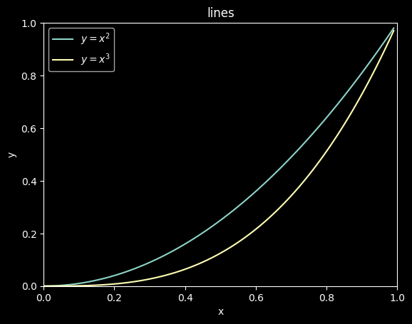

```python
import numpy as np
import matplotlib.pyplot as plt

data = np.arange(0,1.0,0.01)

plt.title('lines') #设置标题
plt.xlabel('x') #设置x轴标签
plt.ylabel('y') #设置y轴标签
plt.xlim((0,1)) #设置x轴范围
plt.ylim((0,1)) #设置y轴范围
plt.xticks([0,0.2,0.4,0.6,0.8,1]) #设置x轴刻度
plt.yticks([0,0.2,0.4,0.6,0.8,1]) #设置y轴刻度
plt.plot(data,data**2) #绘制y=x^2曲线
plt.plot(data,data**3) #绘制y=x^3曲线
plt.legend(['$y=x^2$','$y=x^3$']) #LaTex语法，设置图例

plt.savefig('./tmp/y=x^2 y=x^3.png') #保存图像
```

使用MatPlotLib绘图必须先要创建一个figure（画布）对象，然后创建axes（坐标系）。

因为系统可以自动**隐式创建figure（画布）对象**，所以上例中并没有特意创建figure。

当第一次执行plt.xxx()绘图代码时，系统会自动判断是否已有figure对象，并于缺少时自动创建，同时在这个figure之上自动创建一个axes坐标系。

但是系统自动生成的figure对象上只能有一个axes坐标系，即只能绘制一个图形。如果仅仅需要绘制一个图形，那么直接使用plot.xxx()的方式非常方便。

但如果想要在一个figure对象上绘制多个图形，那么必须获取每个axes对象，然后在每个对应坐标系上进行绘图，此时必须**显式创建figure对象**。

**绘制子图**本质上是多个基础图形绘制过程的叠加，即分别在同一幅画布的不同子区域上绘制图形。

如下所示：（换个虚线）

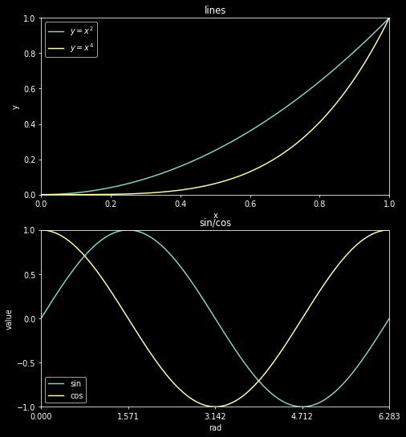

```python
rad = np.arange(0,np.pi*2,0.01) #创建0~2π的等差数组

fig = plt.figure(figsize=(8,9),dpi=70) #创建画布

ax1 = fig.add_subplot(2,1,1) #创建子图1
plt.title('lines') #设置标题
plt.xlabel('x') #设置x轴标签
plt.ylabel('y') #设置y轴标签
plt.xlim((0,1)) #设置x轴范围
plt.ylim((0,1)) #设置y轴范围
plt.xticks([0,0.2,0.4,0.6,0.8,1]) #设置x轴刻度
plt.yticks([0,0.2,0.4,0.6,0.8,1]) #设置y轴刻度
plt.plot(rad,rad**2) #绘制y=x^2曲线
plt.plot(rad,rad**4) #绘制y=x^4曲线
plt.legend(['$y=x^2$','$y=x^4$']) #LaTex语法，设置图例

ax2 = fig.add_subplot(2,1,2) #创建子图2
plt.title('sin/cos') #设置标题
plt.xlabel('rad') #设置x轴标签
plt.ylabel('value') #设置y轴标签
plt.xlim((0,np.pi*2)) #设置x轴范围
plt.ylim((-1,1)) #设置y轴范围
plt.xticks([0,np.pi/2,np.pi,np.pi*1.5,np.pi*2]) #设置x轴刻度
plt.yticks([-1,-0.5,0,0.5,1]) #设置y轴刻度
plt.plot(rad,np.sin(rad)) #绘制sin曲线
plt.plot(rad,np.cos(rad)) #绘制cos曲线
plt.legend(['sin','cos']) #设置图例

plt.show() #显示图像
```

MatPlotLib中设置图形大小的语句为：

```
fig = plt.figure(figsize=(a,b),dpi=dpi)
```

其中：figsize设置图形的大小，a为图形的宽，b为图形的高，单位为英寸；

dpi设置图形每英寸的屏幕像素点数，dpi值越大，显示的图像也越大。

### 3.4 动态参数

使用pyplot进行图形绘制涉及了大量参数设定，虽然某些参数会有默认值，但是更多的参数需要手动设置才能够更好绘制图形。

pyplot使用**rc参数**定义图形的各种属性，例如窗口大小、每英寸点数、线条宽度、颜色、样式、坐标轴、坐标和网格属性、文本、字体等。

所谓rc参数（runtime configuration）即运行时配置参数。根据实际需要，rc参数可在绘图代码中动态更改。

例如线条rc参数修改前后对比：

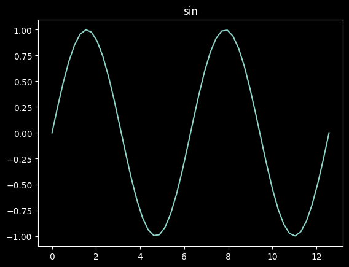

```python
x = np.linspace(0,4*np.pi) #创建0~4π的等差数组
y = np.sin(x) #计算y=sin(x)
plt.plot(x,y,label='$y=sin(x)$') #绘制y=sin(x)曲线
plt.title('sin') #设置标题

plt.show() #显示图像
```

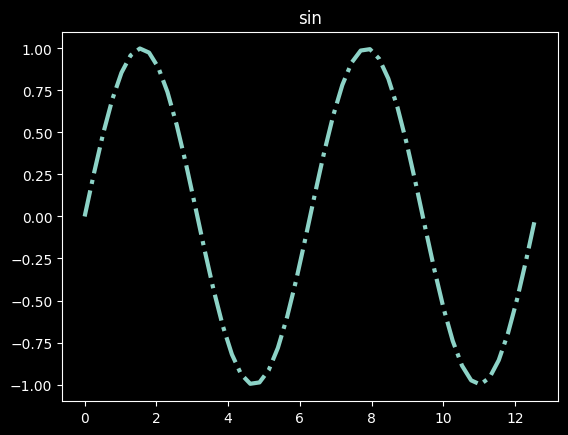

```python
# 修改rc参数后的图像
plt.rcParams['lines.linestyle'] = '-.'
plt.rcParams['lines.linewidth'] = 3
plt.plot(x,y,label='$y=sin(x)$') #绘制y=sin(x)曲线
plt.title('sin') #设置标题

plt.show() #显示图像
```

线条常用的rc参数名称、解释与取值如下表所示：

| rc参数名称 | 解释 | 取值 |
| --- | --- | --- |

[output not shown]

**lines.linestyle常用线条类型参数**4种取值及意义如下表所示：

| linestyle取值 | 意义 |
| --- | --- |
| - | 实线 |
| -. | 点线 |
| -- | 长虚线 |
| : | 短虚线 |

**lines.marker线条标记参数**的20种取值及其意义如下表所示：

| marker取值 | 意义 |
| --- | --- |
| o | 圆圈 |
| d | 菱形 |
| h | 六边形1 |
| H | 六边形2 |
| - | 水平线 |
| 8 | 八边形 |
| p | 五边形 |
| , | 像素 |
| + | 加号 |
| . | 点 |
| s | 正方形 |
| * | 星号 |
| d | 小菱形 |
| v | 一角朝下的三角形 |
| < | 一角朝左的三角形 |
| > | 一角朝右的三角形 |
| ^ | 一角朝上的三角形 |
| \| | 竖线 |
| x | X |
| None | 无 |

### 3.5 绘图示例

MatPlotLib作为Python种最常用的可视化工具之一，具有强大的功能，能方便的调用函数绘制出数据分析中的各种图形，比如折线图、条形图、柱状图、散点图、饼图等。

下表展现了上述图形的定义、特点以及在MatPlotLib中的代码。

| 图表类型 | 定义 | 特点 | 代码 | 说明 |
| --- | --- | --- | --- | --- |
| 折线图 | 以折线的上升以及下降来表示统计数量的增减变化的统计图 | 能够显示数据的变化趋势，反应数据的变化情况 | plt.plot(x,y) | x：x轴刻度；y：y轴刻度 |
| 散点图 | 用两组数据构成多个坐标点，考察坐标点的分布，判断两变量之间是否存在某种关联或者是总结坐标点的分布模式 | 通过散点的“疏密程度”和“变化趋势”表示两个特征的数量关系 | plt.scatter(x,y,s,c,marker,alpha,linewidths) | s：点的大小；c：点的颜色；marker：点的形状；alpha：透明度；linewidths：线宽 |
| 柱状图 | 排列在工作表中的列或者行中的数据可以绘制在柱状图种 | 绘制离散的数据，能够直观了解数据的大小，比较数据之间的差别（统计/对比） | plt.bar(x.height,width,color) | height：柱形的高度；width：柱形的宽度；color：柱形的颜色 |
| 直方图 | 由一系列高度不等的纵向条纹或线段表示数据的分布情况，一般用横轴表示数据范围，纵轴表示分布情况 | 绘制连续性的数据，展示一组或者多组数据的分布情况 | plt.hist(data,bins,facecolor,edgecolor) | bins：区间个数；facecolor：填充颜色；edgecolor：边框颜色 |

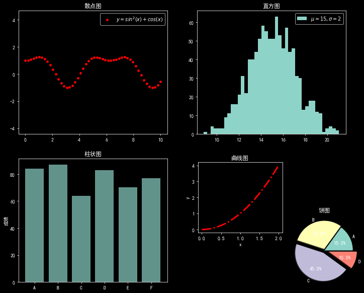

```python
import matplotlib.pyplot as plt
import numpy as np

plt.rcParams['font.sans-serif'] = ['SimHei'] #设置中文显示
plt.rcParams['axes.unicode_minus'] = False #设置显示负号

np.random.seed(101) #设置随机数种子

fig = plt.figure(figsize=(12,10),dpi=70) #创建画布

ax1 = fig.add_subplot(2,2,1) #创建子图1
N = 50
x = np.linspace(0.,10.,N)
y = np.sin(x)**2 + np.cos(x)
ax1.scatter(x,y,s=15,label='$y=sin^2(x)+cos(x)$',color='r') #绘制散点图
ax1.axis('equal') #设置x、y轴刻度相等
ax1.legend() #设置图例
ax1.set_title('散点图') #设置标题

ax2 = fig.add_subplot(2,2,2) #创建子图2
N = 1000
x = np.random.randn(N)*2+15
ax2.hist(x,bins=40,label='$\mu=15,\sigma=2$') #绘制直方图
ax2.legend() #设置图例
ax2.set_title('直方图') #设置标题

ax3 = fig.add_subplot(2,2,3) #创建子图3
name = ['A','B','C','D','E','F']
N = len(name)
math = np.random.randint(60,100,N)
ax3.bar(name,math,alpha=0.7) #绘制柱状图
ax3.set_ylabel('成绩') #设置y轴标签
ax3.set_title('柱状图') #设置标题

left, bottom, width, height = 0.55, 0.25, 0.2, 0.2
ax4 = fig.add_axes([left, bottom, width, height]) #创建子图4
x = np.linspace(0,2,100)
ax4.plot(x,x*x,'r') #绘制y=x^2曲线
ax4.set_xlabel('x') #设置x轴标签
ax4.set_ylabel('y') #设置y轴标签
ax4.set_title('曲线图') #设置标题

left, bottom, width, height = 0.75, 0.1, 0.2, 0.2
ax5 = fig.add_axes([left, bottom, width, height]) #创建子图5
labels = ['A','B','C','D']
sizes = [15,30,45,10]
explode = (0,0.05,0.1,0.15)
ax5.pie(sizes,labels=labels,autopct='%1.1f%%',shadow=True,explode=explode) #绘制饼图
ax5.set_title('饼图') #设置标题

plt.show() #显示图像
```